# Notebook

### Фактический запуск 14.09.2026

Все вычислительные ячейки выполнены. Техническое исполнение не подтверждает научные интерпретации исторического текста. Полный журнал — `legacy-execution.json`.

## Статус воспроизведения исторической редакции

Повторный технический запуск не подтверждает научные выводы старой редакции. Ниже сохранены прежние допущения и интерпретации; их следует сверять с текущими правилами проекта. Дыхательная и ЭКГ-разметка исторических расчётов не получает статус принятой при повторном запуске. Значения толщины 15 и 40 мм — исторические сценарии, а не заново проверенные измерения по КТ. Старые оценки сердечного происхождения сигнала и функций сердца не считаются валидированными.

```
Исторические входы скопированы; запись в исходные метки и параметры исключена.
```

# Указатель происхождения: 17_Дрейф_опорного_канала_и_порядок_съёмки.ipynb

> **Статус:** санифицированный указатель, а не копия исходного расчёта.
- Исходный путь: `Colab Notebooks/17_Дрейф_опорного_канала_и_порядок_съёмки.ipynb`.
- Исходный коммит: `1ac7813654b59861e359cffe3ad40941baeab2d9`.
- Контрольные суммы и ID ячеек: `../../MIGRATION_MANIFEST_2026-08-26.json`.
- Текущий действующий владелец до проверенного разделения: `../../10.01_QC_эксперимента_2_порядок_и_каналы.ipynb`.
- Локальный несанифицированный снимок при необходимости хранится в `../private/` и исключён из Git.

Исходные ячейки восстановлены ниже из указанного коммита. Эта редакция остаётся исторической.

# Дрейф опорного канала и порядок съёмки — диагностика эксперимента EXP_2026_04_29

Цель — проверить, можно ли по данным эксперимента отделить влияние **размера электродной сборки** от влияния **времени съёмки**, и оценить, что вносит в результат дрейф измерительного тракта.

Повод. В 09 §2.2 обнаружены отклонения кривой зондирования от гладкого хода, воспроизводящиеся у двух испытуемых на одних и тех же номинальных размерах сборки. Естественное объяснение — свойство сборки. Настоящий ноутбук проверяет конкурирующее объяснение: изменение состояния измерительного тракта и кожи по ходу сессии.

Ключ к проверке — **канал 1**. Это трансторакальный опорный канал, его электроды в течение всей сессии не переставлялись, тогда как сборка канала 2 менялась перед каждой записью. Поэтому любое изменение канала 1 между записями относится ко времени, а не к размеру сборки.

## §0. Методика и словарь терминов

### Решаемая задача

Требуется установить, является ли зависимость измеряемых величин от номинального размера электродной сборки следствием самого размера либо следствием положения записи во времени сессии, и оценить величину дрейфа измерительного тракта.

### Метод и обоснование выбора

Используется канал с неизменной конфигурацией электродов как индикатор состояния тракта. Если величина, измеряемая неизменным монтажом, систематически меняется между записями, изменение принадлежит тракту, испытуемому или контакту, но не геометрии сменной сборки. Порядок записей восстанавливается по времени создания файлов, поскольку в протоколе эксперимента тайминги не фиксировались.

### Словарь терминов

- **Опорный канал (канал 1)** — трансторакальное отведение, электроды которого не переставлялись в течение сессии; величина `BASE_1`, Ом.
- **Рабочий канал (канал 2)** — лёгочная сборка, сменяемая перед каждой записью; величина `BASE_2`, Ом.
- **Порядок съёмки** — номер записи в сессии, восстановленный по времени создания файла.
- **Дрейф** — систематическое изменение величины, измеряемой неизменным монтажом, по ходу сессии.
- **Показатель QS** — импеданс между токовыми электродами канала, Ом; столбцы `QS_1_Ω` и `QS_2_Ω`. Характеризует замкнутость и качество токовой цепи, а не измеряемую ткань. Значение 4700 Ом — потолок шкалы, соответствующий разомкнутой цепи: он наблюдается у заведомо отключённых каналов (16 §4).
- **Ревизия прибора** — версия аппаратуры. Записи РНЦХ и МГТУ сделаны **разными ревизиями одного прибора**, и ревизии ведут себя существенно по-разному. В ревизии МГТУ одно из двух измерений QS неработоспособно, поэтому оба столбца несут одно значение. Прямое сопоставление величин QS между двумя экспериментами недопустимо; сопоставлять можно только качественные признаки.
- **Смешение факторов** — ситуация, в которой два фактора изменяются согласованно, отчего их раздельное влияние не определяется никакой обработкой данных этого эксперимента.
- **Отклонение от гладкого хода** — величина δ по формуле (9.10) из 09 §2.2, %.

### Как оценивать результаты

Смешение считается полным, если порядок съёмки является монотонной функцией размера сборки: тогда коэффициенты корреляции любой величины с размером и с порядком совпадают по модулю, и статистического способа их различить не существует. Дрейф считается значимым, если его размах превышает разброс между соседними записями. Запись признаётся дефектной, если величина по опорному каналу выходит за пределы разброса остальных записей более чем в два раза.

**Входные данные.** Исходные записи эксперимента `EXP_2026_04_29_BMSTU_REOCARDIO_GEORG_NIX` с диска `Z:` — файлы `<L><испытуемый>.csv` с каналами `TIME_s`, `BASE_1_Ω`, `BASE_2_Ω`; время создания и контрольная сумма каждого файла; границы режимов дыхания из меток `timestamps/` (08).

**Допущения.** Время создания файла принимается за время окончания записи. Это допущение проверяется на согласованность: интервалы между соседними записями должны быть сопоставимы с длительностью записи плюс время перестановки сборки. Уровень канала берётся как медиана на плато задержки дыхания с отступом 0.5 с от границ, чтобы исключить переходные участки; медиана выбрана как устойчивая к выбросам оценка.

```
Загружено записей: {'Ник': 9, 'Георгий': 10}
Столбцы QS_1 и QS_2 совпадают во всех записях: да
```

**Анализ результатов.** Загружены уровни обоих каналов на двух задержках для 9 записей Ника и 10 записей Георгия, а также время создания и контрольная сумма каждого файла.

**Результаты и умозаключения.** Полученная таблица — вход для §1 (порядок съёмки), §2 (дрейф) и §4 (сопоставление с отклонениями кривой зондирования).

## §1. Восстановление порядка съёмки и проверка происхождения файлов

В протоколе эксперимента тайминги записей не фиксировались, поэтому порядок восстанавливается по времени создания файлов. Одновременно проверяется происхождение каждого файла по контрольной сумме.

**Входные данные.** Время создания и контрольная сумма файлов записей из технического блока выше.

**Допущения.** Совпадение контрольных сумм двух файлов означает, что один является копией другого, а не независимой записью. Подлинной считается запись, время создания которой попадает внутрь сессии и в интервал, согласованный с соседними записями.

```
=== Ник — h=15 мм ===
   №   L,мм |              создан |    мин |        md5
   1    140 | 2026-04-29 18:52:58 |    0.0 | 3f3d033baf
   2    130 | 2026-04-29 18:57:28 |    4.5 | 7f8f422795
   3    120 | 2026-04-29 19:00:44 |    7.8 | a14c8eec80
   4    110 | 2026-04-29 19:04:26 |   11.5 | d65625fb9a
   5     90 | 2026-04-29 19:11:16 |   18.3 | f8795f532a
   6     80 | 2026-04-29 19:15:42 |   22.7 | 6bd27d449c
   7     70 | 2026-04-29 19:19:28 |   26.5 | 694c3a998c
   8     60 | 2026-04-29 19:23:36 |   30.6 | b21295786d
   9     50 | 2026-04-29 19:28:36 |   35.6 | 0fe4de475c
  порядок строго по убыванию размера: да | длительность сессии 36 мин

=== Георгий — h=40 мм ===
   №   L,мм |              создан |    мин |        md5
   1    140 | 2026-04-29 17:39:10 |    0.0 | fe088548ac
   2    130 | 2026-04-29 17:44:30 |    5.3 | 9dfe049018
   3    120 | 2026-04-29 17:49:04 |    9.9 | f8da43522c
   4    110 | 2026-04-29 17:54:52 |   15.7 | 21907e0dbd
   5    100 | 2026-04-29 17:59:50 |   20.7 | 31974096c9
   6     90 | 2026-04-29 18:03:22 |   24.2 | 5b69330869
   7     80 | 2026-04-29 18:06:12 |   27.0 | 8cf3be47c2
   8     70 | 2026-04-29 18:08:56 |   29.8 | d33d42172a
   9     60 | 2026-04-29 18:12:28 |   33.3 | c59e3b8b26
  10     50 | 2026-04-29 18:16:22 |   37.2 | 7eaf8b944c
  порядок строго по убыванию размера: да | длительность сессии 37 мин

Проверка контрольных сумм по всем файлам на диске:
  Ник: совпадают 100nik.csv (2026-05-04 18:17), 90nik.csv (2026-04-29 19:11)
```

**Анализ результатов.** У обоих испытуемых записи выполнялись строго по убыванию размера сборки, от 140 мм к 50 мм. Сессия Георгия длилась 37 минут, сессия Ника 36 минут; интервалы между соседними записями составляют 3–7 минут, что согласуется с длительностью записи около 80 с плюс перестановка сборки. Согласованность интервалов подтверждает допущение о том, что время создания файла отражает время записи.

Проверка контрольных сумм выявила совпадение файлов `90nik.csv` и `100nik.csv`. Файл `90nik.csv` создан 2026-04-29 в 19:11:16, то есть внутри сессии и на своём месте убывающей последовательности между записями 110 мм (19:04) и 80 мм (19:15). Файл `100nik.csv` создан 2026-05-04, через пять дней после сессии. Следовательно подлинной является запись 90 мм; запись 100 мм была случайно перезаписана и не восстановима.

**Результаты и умозаключения.** Порядок съёмки является строго убывающей функцией размера сборки, одинаковой у обоих испытуемых. Следовательно номер записи и размер сборки связаны взаимно однозначно и монотонно: **эти два фактора полностью смешаны**. Никакая обработка данных этого эксперимента не позволит приписать наблюдаемую зависимость одному из них — корреляция любой величины с размером тождественна её корреляции с порядком съёмки, с точностью до знака.

Установленное происхождение файлов учтено в 09 §1: из анализа исключается запись 100 мм, а не 90 мм, как считалось ранее.

## §2. Дрейф опорного канала в зависимости от размера сборки и от времени

Основной раздел. Опорный канал 1 измеряется неизменным монтажом, поэтому его зависимость от размера сменной сборки физически невозможна. Всё, что выглядит как такая зависимость, является зависимостью от времени, отображённой на ось размера через порядок съёмки.

**Входные данные.** Медианный базовый импеданс каналов 1 и 2 на плато задержки вдоха и задержки выдоха, номер записи и время от начала сессии — из технического блока.

**Допущения.** Конфигурация электродов канала 1 в течение сессии не менялась. Следовательно изменение `BASE_1` между записями относится к состоянию кожи, электродного геля, контакта либо самого испытуемого, но не к геометрии сборки канала 2. Сопоставление ведётся в трёх координатах — размер сборки, номер записи и время от начала сессии, — чтобы показать, что это три представления одних и тех же данных.

Показатель QS привлекается как независимый от базового импеданса признак качества контакта. Он интерпретируется только качественно: низкая медиана и выход на потолок 4700 Ом трактуются как ухудшение контакта, поскольку тот же потолок наблюдается у заведомо отключённых каналов (16 §5). Количественная трактовка невозможна до расшифровки шкалы.

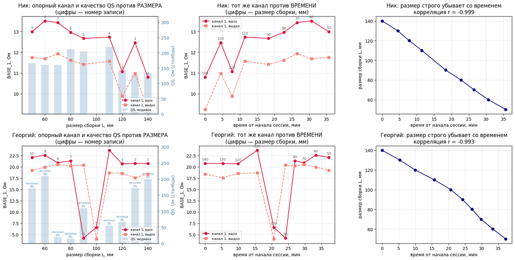

```
субъект  | канал 1 (монтаж НЕ менялся)  | канал 2 (сборка менялась)
----------------------------------------------------------------------------
Ник      | 10.79 -> 12.99 Ом ( +20.3 %) |  50.10 ->  85.69 Ом ( +71.0 %)
         |  r с номером записи +0.804      |  r с размером -0.941
         |  r с размером       -0.809      |
Георгий  | 20.75 -> 22.11 Ом (  +6.6 %) | 115.92 -> 199.48 Ом ( +72.1 %)
         |  r с номером записи +0.044      |  r с размером -0.966
         |  r с размером       -0.044      |

Показатель качества QS по записям (медиана на задержке вдоха):
субъект  |  L,мм | QS мед,Ом | на потолке % |    QS=0, %
------------------------------------------------------------
Ник      |   140 |       135 |        0.0% |      12.8%
Ник      |   130 |       129 |        0.0% |      11.4%
Ник      |   120 |       143 |        0.0% |      12.1%
Ник      |   110 |       220 |        0.0% |      10.1%
Ник      |    90 |       204 |        0.0% |      10.7%
Ник      |    80 |       212 |        0.0% |      11.3%
Ник      |    70 |       160 |        0.0% |      15.2%
Ник      |    60 |       160 |        0.0% |      11.7%
Ник      |    50 |       166 |        0.0% |      11.1%
Ник      | размах медианы QS 129–220 Ом, корреляция с размером r = -0.338

Георгий  |   140 |       200 |        2.4% |      17.7%
Георгий  |   130 |       172 |        1.9% |      24.3%
Георгий  |   120 |        66 |        2.5% |      23.8%
Георгий  |   110 |        55 |        0.9% |      35.0%
Георгий  |   100 |         0 |        0.0% |      24.0%
Георгий  |    90 |       109 |        1.5% |       9.9%
Георгий  |    80 |        14 |        3.6% |      29.6%
Георгий  |    70 |        19 |        1.5% |      28.5%
Георгий  |    60 |       209 |        2.6% |      20.6%
Георгий  |    50 |       170 |        4.4% |      26.4%
Георгий  | размах медианы QS 0–209 Ом, корреляция с размером r = +0.058
```

**Анализ результатов.** Левый столбец отвечает на поставленный вопрос буквально: базовый импеданс опорного канала явно зависит от размера сборки. У Ника он растёт с 10.79 Ом на сборке 140 мм до 13.51 Ом на сборке 60 мм — размах 25 % — и составляет 12.99 Ом на сборке 50 мм. У Георгия изменение меньше по размаху и немонотонно: 20.75 Ом на 140 мм, провалы до 6.59 и 4.21 Ом на 100 и 90 мм, 22.11 Ом на 50 мм.

Правый столбец объясняет причину совпадения. Размер сборки убывает со временем строго монотонно, коэффициент корреляции по модулю равен единице. Поэтому график «против размера» и график «против времени» — это одни и те же данные в зеркально отражённой и нелинейно растянутой оси абсцисс. Коэффициент корреляции опорного канала с номером записи и с размером сборки совпадает по модулю и различается знаком: у Георгия +0.044 и −0.044 в точности, у Ника +0.804 и −0.809 — расхождение в третьем знаке возникает лишь потому, что у него отсутствует запись 100 мм и шаг по размеру неравномерен. Совпадение по модулю и есть формальный признак полного смешения факторов.

Показатель QS — импеданс между токовыми электродами — даёт независимую от базового импеданса картину состояния токовой цепи. В этой сессии столбцы `QS_1_Ω` и `QS_2_Ω` совпадают во всех девятнадцати записях, тогда как в РНЦХ они различались (`QS1≈1307`, `QS2≈368` Ом, 16 §5). Причина известна: использованная здесь ревизия прибора имеет одно из двух измерений QS неработоспособным, и рабочее значение попадает в оба столбца.

Какой именно токовой паре принадлежит уцелевшее измерение, по этим данным установить не удалось. Корреляция медианы QS с базовым импедансом канала 1 составляет +0.44 у Ника и +0.28 у Георгия, с базовым импедансом канала 2 — +0.28 и +0.01; ни одна не выделяется. Слабый довод в пользу канала 2 даёт характер изменчивости: QS меняется между соседними записями в среднем на 13.5 % против 6.5 % у базового импеданса канала 1 и не воспроизводит его монотонный дрейф (корреляция с номером записи +0.33 против +0.80). Такая скачкообразность естественна для электродов, переклеиваемых перед каждой записью, и несвойственна неизменному монтажу. Довод недостаточен для вывода; решающая проверка описана в §4.1.

Между испытуемыми QS различается принципиально. У Ника медиана лежит в узком диапазоне 129–220 Ом и **ни в одной записи не достигает потолка** 4700 Ом. У Георгия медиана меняется от 0 до 209 Ом, потолок достигается в девяти записях из десяти на 0.9–4.4 % отсчётов, а доля нулевых значений доходит до 35 % против стабильных 10–15 % у Ника. Это указывает на систематически худшее качество контакта у Георгия и согласуется с тем, что именно у него обнаружены записи с отказом опорного канала (§3).

Существенно для основного вопроса, что QS **не зависит от размера сборки**: корреляция медианы QS с размером составляет −0.34 у Ника и +0.06 у Георгия, то есть неотличима от нуля при девяти и десяти точках. Следовательно качество контакта не выстроено вдоль оси размера и не может объяснить воспроизводящиеся между испытуемыми отклонения кривой зондирования из 09 §2.2.

> **Существенная оговорка о канале 1.** Канал 1 прибора МГТУ даёт заведомо неверные абсолютные значения (§4.2). Поэтому его показания используются здесь **только как индикатор изменения во времени**, а не как измерение импеданса: неисправность, дающая устойчивое занижение уровня, не обязана уничтожать относительный ход. Тем не менее вывод о наличии дрейфа сессии опирается на неисправный тракт, и его следует считать предварительным до получения исправного опорного канала.

**Результаты и умозаключения.** Дрейф измерительного тракта в сессии реален и по величине сопоставим с изучаемыми эффектами: 25 % у Ника при том, что отклонения кривой зондирования, обсуждаемые в 09 §2.2, составляют 4–5 %. Демонстрация показывает, что зависимость от размера сборки в этом эксперименте не является доказательством причинной связи с размером, и относится в равной мере к каналу 2. Отсюда требование к постановке следующего эксперимента — рандомизация порядка наложения сборок (09 §2.2.1, мера 1).

## §3. Дефектные записи по опорному каналу

Опорный канал позволяет не только оценить дрейф, но и выявить записи, выполненные при нарушенном контакте.

**Входные данные.** Уровни канала 1 на задержке вдоха по всем записям каждого испытуемого.

**Допущения.** При исправном контакте базовый импеданс неизменного монтажа меняется плавно, поскольку его определяют свойства тканей и электродов, а они между соседними записями заметно не меняются. Запись признаётся дефектной, если её уровень отклоняется от медианы по испытуемому более чем вдвое: такое отклонение не объяснимо ни дрейфом, ни физиологией и указывает на потерю контакта.

```
субъект  |  L,мм |     BASE_1 |  к медиане | вердикт
------------------------------------------------------------------
Ник      |   140 |      10.79 |      0.85× |
Ник      |   130 |      12.46 |      0.98× |
Ник      |   120 |      11.07 |      0.87× |
Ник      |   110 |      12.72 |      1.00× |
Ник      |    90 |      12.66 |      1.00× |
Ник      |    80 |      12.96 |      1.02× |
Ник      |    70 |      13.42 |      1.06× |
Ник      |    60 |      13.51 |      1.06× |
Ник      |    50 |      12.99 |      1.02× |
Ник      | медиана 12.72 Ом, дефектных записей: нет

Георгий  |   140 |      20.75 |      1.00× |
Георгий  |   130 |      20.75 |      1.00× |
Георгий  |   120 |      20.67 |      0.99× |
Георгий  |   110 |      23.67 |      1.14× |
Георгий  |   100 |       6.59 |      0.32× | ДЕФЕКТ
Георгий  |    90 |       4.21 |      0.20× | ДЕФЕКТ
Георгий  |    80 |      21.32 |      1.02× |
Георгий  |    70 |      20.89 |      1.00× |
Георгий  |    60 |      22.58 |      1.08× |
Георгий  |    50 |      22.11 |      1.06× |
Георгий  | медиана 20.82 Ом, дефектных записей: [100, 90]
```

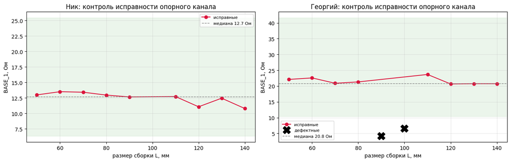

**Анализ результатов.** У Ника все девять записей находятся в пределах 0.85–1.06 медианы (12.72 Ом), дефектных нет. У Георгия записи 100 мм и 90 мм дают 6.59 и 4.21 Ом против медианы около 21 Ом, то есть 0.31 и 0.20 медианы — падение в три и в пять раз при неизменном монтаже. Прочие восемь записей укладываются в 0.99–1.14 медианы (20.82 Ом).

Физиологического объяснения такому падению нет: удельное сопротивление тканей между соседними записями не меняется в разы. Остаётся нарушение контакта одного из электродов опорного канала — отклеивание, высыхание геля либо задевание провода при перестановке сборки канала 2.

Существенно, что эти две записи затрагивают и рабочий канал: если контакт был нарушен при перестановке, канал 2 мог пострадать в тех же записях, хотя по нему это не диагностируется, поскольку его монтаж менялся штатно.

**Результаты и умозаключения.** Записи 100 мм и 90 мм у Георгия признаются недостоверными по опорному каналу. Это касается наибольшего по модулю отклонения в 09 §2.2 — на сборке 90 мм у Георгия оно равно −7.0 %, то есть один из четырёх размеров, формирующих корреляцию между испытуемыми, опирается на дефектную запись. Повторение §2.2 без этих записей приведено в §4.

**Сопоставление с показателем QS.** Два индикатора качества выделяют разные записи и потому дополняют друг друга. Запись 100 мм у Георгия отмечена обоими: базовый импеданс опорного канала составляет 0.32 медианы, а медиана QS равна нулю при полном отсутствии выходов на потолок — режим, не встречающийся ни в одной другой его записи, где потолок достигается всегда. Запись 90 мм, наихудшая по опорному каналу (0.20 медианы), по QS выглядит благополучно: медиана 109 Ом, доля нулевых значений 9.9 % — наименьшая у этого испытуемого.

Расхождение означает, что величины отражают разные стороны измерения, и до расшифровки шкалы QS (16 §5) объединять их в один критерий преждевременно. Для выбраковки записей здесь используется опорный канал, поскольку его физический смысл известен; QS приводится как независимое свидетельство.

## §4. Влияние дрейфа и дефектных записей на отклонения кривой зондирования

Раздел связывает диагностику с результатом 09 §2.2: проверяется, объясняются ли найденные там отклонения дрейфом опорного канала и сохраняются ли они после исключения дефектных записей.

**Входные данные.** Уровни каналов 1 и 2 на задержке вдоха; список дефектных записей из §3.

**Допущения.** Отклонение δ вычисляется по формуле (9.10) из 09 §2.2: кажущееся удельное сопротивление, гладкий ход в виде многочлена второй степени по логарифму размера, относительная разность. Если отклонения порождены дрейфом тракта, они должны коррелировать с уровнем опорного канала. Если они принадлежат размеру сборки, исключение дефектных записей не должно разрушить совпадение между испытуемыми.

```
Ник      | корреляция δ с уровнем опорного канала: r = +0.242 (n=9)
Георгий  | корреляция δ с уровнем опорного канала: r = +0.321 (n=10)
```

```
все записи     | общих размеров 9 | корреляция r = +0.753 | совпадение знака 8 из 9
без дефектных  | общих размеров 8 | корреляция r = +0.700 | совпадение знака 6 из 8
```

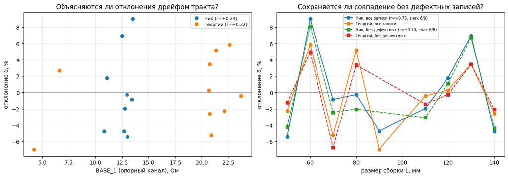

**Анализ результатов.** Связь отклонений δ с уровнем опорного канала слабая — коэффициенты корреляции приведены в легенде левого графика и по модулю не достигают величины, значимой при девяти и десяти точках. Следовательно отклонения кривой зондирования не сводятся к тому же процессу, который вызывает дрейф опорного канала. Это ослабляет, но не снимает объяснение через время: дрейф контакта канала 1 и изменение свойств сборки канала 2 могут иметь разную временную форму.

По всем записям совпадение между испытуемыми характеризуется коэффициентом корреляции +0.753 при совпадении знака в 8 случаях из 9. После исключения двух дефектных записей Георгия остаётся 8 общих размеров, корреляция составляет +0.700, совпадение знака 6 из 8. Обе меры снижаются незначительно, то есть совпадение отклонений между испытуемыми **не создаётся дефектными записями** и сохраняется после их удаления. Вместе с тем доля совпадений знака 6 из 8 при восьми точках статистически слаба: вероятность получить такой результат случайно составляет около 14 %.

**Результаты и умозаключения.** Прямое объяснение отклонений дрейфом опорного канала не подтверждается. При этом смешение размера с порядком съёмки (§1) остаётся в силе и не устраняется никакой обработкой, поэтому вывод 09 §2.2 сохраняет статус наблюдения без установленной причины.

## §4.1. Межканальное влияние как кандидат на объяснение систематики

Тест поочерёдного отключения каналов в РНЦХ (16 §4) выполнялся **без отклеивания электродов** от испытуемого, поэтому его результат относится к самому прибору, а не к установке электродов. При совместной работе базовый импеданс составлял 54 Ом на канале 1 и 41 Ом на канале 2; при отключении канала 2 первый возрастал примерно до 93 Ом, при отключении канала 1 второй снижался до 37 Ом. Влияние двустороннее и **резко несимметричное**: канал 1 меняется на 72 %, канал 2 на 10 %.

С учётом того, что QS есть импеданс между токовыми электродами, картина получает объяснение. У одиночно работающего канала 1 QS выходил на потолок 4700 Ом, то есть его токовая цепь выглядела разомкнутой, и одновременно базовый импеданс завышался до 93–101 Ом против 54 Ом при совместной работе. Это соответствует представлению о том, что токовые контуры двух каналов замкнуты через тело и через общие цепи прибора: присутствие второго генератора создаёт параллельный путь, снижающий эффективный импеданс контура первого. При отключении второго канала этот путь исчезает.

Отсюда следствие для настоящего эксперимента. В каждой из девятнадцати записей МГТУ **оба канала работали одновременно**, причём канал 1 сохранял неизменный монтаж, а сборка канала 2 меняла размер. Если величина межканального влияния зависит от геометрии сборки, то она добавляет к измеренному базовому импедансу канала 2 вклад, зависящий от размера. Такой вклад:

1. определяется прибором и геометрией электродов, а не испытуемым, и потому **обязан воспроизводиться у разных людей** — что и наблюдается в 09 §2.2 при корреляции 0.75 и 0.70;
2. не требует существования сборки как долговечного предмета и потому совместим с тем, что сборки набирались из одноразовых электродов;
3. не связан с порядком съёмки и потому не устраняется рандомизацией.

По объяснительной силе этот механизм превосходит ранее рассматривавшиеся отличие фактической геометрии от номинальной и качество контакта: первое требует многоразового шаблона разметки, второе опровергается отсутствием зависимости QS от размера (§2). Настоящие данные его не подтверждают и не опровергают: в них нет ни одной записи с отключённым каналом 1.

**Решающая проверка.** Повторить протокол `14-17-16` из 16 на аппаратуре МГТУ для каждого размера сборки, не отклеивая электроды: измерить базовый импеданс канала 2 при работающем и при отключённом канале 1. Разность как функция размера прямо измеряет искомый вклад. Дополнительно это устанавливает, какой токовой паре принадлежит уцелевшее измерение QS: при отключении канала 1 оно либо выйдет на потолок, либо не изменится. Проверка занимает одну сессию, может выполняться на фантоме и **должна предшествовать** калибровке сборок (09 §2.2.1): при наличии межканального влияния калибровка одиночной сборки измерит не ту величину.

**Ограничение переноса.** Числа теста РНЦХ получены другой ревизией прибора и на другом монтаже, поэтому переносятся на МГТУ только как указание на механизм и его порядок величины, но не как поправка.

## §4.2. Канал 1 в МГТУ неисправен, и это объясняет расхождение COMSOL

Уточнение постановки теста поочерёдного отключения: электроды с испытуемого **не снимались**, из прибора извлекался кабель соответствующего канала. Следовательно электрод-кожный переход в тесте неизменен, а размыкается токовая цепь на стороне прибора. Это уточняет механизм из §4.1: подключённый второй канал добавляет через входные цепи прибора проводящий путь между двумя точками тела, и этот путь шунтирует измерение первого канала. При извлечении кабеля шунт исчезает.

Сопоставление трёх независимых источников по одному и тому же монтажу канала 1 — трансторакальному, с одинаковым расположением электродов на обеих площадках — даёт согласованную картину:

[output not shown]

Остаточное расхождение между расчётом (`100+ Ом`, одиночная пара) и измерением РНЦХ при обоих включённых каналах (`54 Ом`) объясняется межканальным шунтом и требует либо расчёта с двумя токовыми парами, либо сопоставления с одноканальным измерением.

**Статус утверждения.** Это гипотеза с сильной поддержкой, а не установленный факт. В её пользу: совпадение расчёта с независимым измерением исправного прибора, одинаковое расположение электродов канала 1 на обеих площадках, известная неисправность канала 1 в ревизии МГТУ. Против: площадки различаются ревизией прибора, испытуемые в РНЦХ и МГТУ разные, а прямого измерения исправным прибором на Нике нет. Решающей проверкой будет измерение трансторакального импеданса Ника исправным прибором.

**Следствие для настоящего ноутбука.** Все выводы §2 и §3, опирающиеся на канал 1, относятся к неисправному тракту. Дрейф во времени при этом сохраняет смысл как относительная величина, а обнаруженные в §3 провалы уровня остаются признаком нештатного состояния, поскольку выделяются на фоне собственного уровня канала. Абсолютные значения канала 1 в МГТУ не подлежат физической интерпретации.

## §5. Выводы

1. **Порядок съёмки полностью смешан с размером сборки.** У обоих испытуемых записи выполнялись строго по убыванию размера, от 140 мм к 50 мм, за 36–37 минут. Коэффициент корреляции размера со временем по модулю равен единице, поэтому никакая обработка данных этого эксперимента не разделит два фактора.
2. **Дрейф измерительного тракта реален и велик.** Базовый импеданс опорного канала, монтаж которого не менялся, изменяется за сессию на 25 % у Ника. Это в пять раз превышает величину отклонений кривой зондирования, обсуждаемых в 09 §2.2.
3. **Видимая зависимость опорного канала от размера сборки — артефакт представления.** Она физически невозможна, так как электроды канала 1 не переставлялись, и целиком объясняется тем, что размер убывает со временем. Тот же артефакт в равной мере возможен и для канала 2, где он неотличим от истинной зависимости.
4. **Две записи Георгия выполнены при нарушенном контакте опорного канала** — 100 мм и 90 мм, уровень 0.31 и 0.20 медианы. Одна из них даёт наибольшее по модулю отклонение в 09 §2.2.
5. **Показатель QS общий для обоих каналов и от размера сборки не зависит.** Столбцы `QS_1_Ω` и `QS_2_Ω` совпадают во всех записях сессии; корреляция медианы QS с размером составляет −0.34 и +0.06. Качество контакта у Георгия систематически хуже: потолок шкалы достигается в девяти записях из десяти, тогда как у Ника не достигается ни разу. Объяснить отклонения кривой зондирования качеством контакта нельзя.
6. **Прямая связь отклонений с дрейфом опорного канала не обнаружена** (корреляция по модулю не выше 0.35), поэтому отклонения не сводятся к тому же процессу. Причина остаётся неустановленной.
7. **Запись 100 мм у Ника не существует.** Файл с этим именем создан через пять дней после сессии и совпадает по контрольной сумме с записью 90 мм; исходная запись случайно перезаписана и не восстановима. Учтено в 09 §1 и 11.

**Требование к постановке следующего эксперимента.** Порядок наложения сборок рандомизируется, причём разной последовательностью для разных испытуемых; фактическое время каждой записи протоколируется; опорный канал контролируется на исправность перед каждой записью. Это единственный способ разделить свойство размера и свойство времени; обработка имеющихся записей его не заменяет (09 §2.2.1, мера 1).

8. **Ревизии прибора различаются существенно.** Записи РНЦХ и МГТУ сделаны разными ревизиями одного прибора; в ревизии МГТУ одно из двух измерений QS неработоспособно. Величины QS между двумя экспериментами несопоставимы, сопоставимы только качественные признаки. Это ограничение первого порядка для любого объединения данных двух площадок.
9. **Межканальное влияние — ведущий кандидат на объяснение систематики по размеру** (§4.1). Оно определяется прибором и геометрией, а не испытуемым, поэтому обязано воспроизводиться у разных людей, не требует сборки как долговечного предмета и не устраняется рандомизацией порядка. Проверяется повторением протокола поочерёдного отключения каналов для каждого размера сборки.
10. **Канал 1 прибора МГТУ неисправен по абсолютной величине** (§4.2). На одном и том же трансторакальном монтаже расчёт МКЭ даёт `100+ Ом`, измерение РНЦХ при отключённом втором канале `93–101 Ом`, при обоих включённых `54 Ом`, а прибор МГТУ — `11.9 Ом`. Абсолютные значения канала 1 в этом эксперименте физической интерпретации не подлежат; относительный ход во времени сохраняет смысл.
11. **Расхождение COMSOL, по-видимому, объясняется эталоном, а не моделью.** Значение `Z1_TRKG = 12.703 Ом`, вокруг которого построен разбор COMSOL_investigation_NIX, принадлежит неисправному каналу 1 прибора МГТУ, тогда как расчёт совпадает с исправным измерением того же монтажа. Требуется измерение трансторакального импеданса Ника исправным прибором.